# Erupción de Volcanes en Indonesia

Ernesto Álvarez

2024-03-04

# Introducción

Indonesia, un país con más de **13,000 islas**, se sitúa en el “*Anillo de Fuego del Pacífico*”, una región conocida por su intensa actividad sísmica y volcánica. Esta ubicación expone al país a constantes riesgos de terremotos y erupciones volcánicas. Se estima que posee **127 volcanes activos** distribuidos a lo largo del país, desde el noroeste de Sumatra hasta las remotas islas del este, como la isla Banda.

Con una población de más de **270 millones** de personas, las erupciones volcánicas representan una amenaza importante para la vida y los bienes de los habitantes de Indonesia. Estos eventos pueden provocar una serie de desastres naturales, como flujos de lava, caída de cenizas, tsunamis volcánicos y deslizamientos de lodo, que pueden causar devastación en las comunidades locales y afectar áreas más extensas.

La investigación y comprensión de los datos sobre erupciones volcánicas a lo largo del tiempo son esenciales para mejorar la preparación y la respuesta ante futuras catástrofes. Este estudio tiene como objetivo **examinar los registros de erupciones desde el año** **1300 hasta la actualidad**, centrándose especialmente en aquellas que han tenido consecuencias mortales. Al visualizar estos datos, se pretende compartir la historia de estas erupciones, aprender de ellas y desarrollar estrategias más efectivas para mitigar los riesgos asociados con estos fenómenos naturales.

Instalaremos y cargaremos los paquetes que usaremos. Además, crearemos una función para crear el “lienzo” de los gráficos:

```r
fig <- function(width, heigth){
     options(repr.plot.width = width, repr.plot.height = heigth)
}
```

```r
library(tidyverse)
library(dplyr)
library(lubridate)
library(janitor)
library(skimr)
```

```r
library(cowplot)
options(warn=-1, message=FALSE)
```

# Carga de datos

Cargamos los datos desde su ubicación en el dispositivo y estandarizaremos los nombres de las columnas:

```r
volcano_events <- read_csv("C:/Users/ERNESTO CAM/Documents/volcano-events-1300-2021.csv", show_col_type=FALSE)
```

```r
v_events <- volcano_events %>% clean_names()
# glimpse(v_events)
# skim_without_charts(v_events)
```

Una pieza esencial de información ausente es el **Índice de Explosividad Volcánica *(VEI)***, de acuerdo con Newhal y Self en 1982. En el caso de erupciones históricas que claramente fueron explosivas pero no tienen otros detalles descriptivos, **se les asigna un VEI predeterminado de 2**.

```r
v_events <- v_events %>% mutate(vei = if_else(is.na(vei), 2, vei),
                               total_deaths = if_else(is.na(total_deaths), 0, total_deaths))
# glimpse(v_events)
```

# Observación de datos

Ahora vamos a examinar los datos desde distintos puntos de vista. ¿Qué podemos inferir desde cada uno de ellos?

## Ubicación del Monte

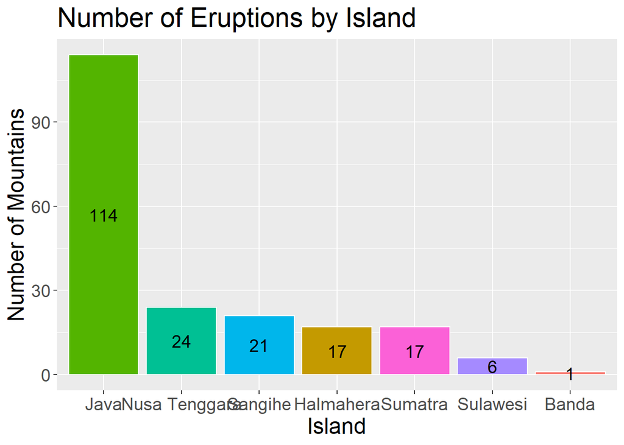

```r
fig(12, 7)
n_eruptbyisland <- v_events %>%
  group_by(island) %>%
  summarize(cnt_mount=n())

ggplot(data=n_eruptbyisland, aes(x=reorder(island, -cnt_mount), y=cnt_mount, fill=island)) +
  geom_bar(stat="identity", width=0.9, color="white") +
  geom_text(aes(label=cnt_mount), position=position_stack(vjust=0.5), size=5) +
  labs(title="Number of Eruptions by Island") +
  xlab("Island") +
  ylab("Number of Mountains") +
  theme(legend.position = "none", text = element_text(size=18))
```

## Las diez erupciones volcánicas más destacadas de montes

Se presentan las diez erupciones principales que han ocurrido en montes:

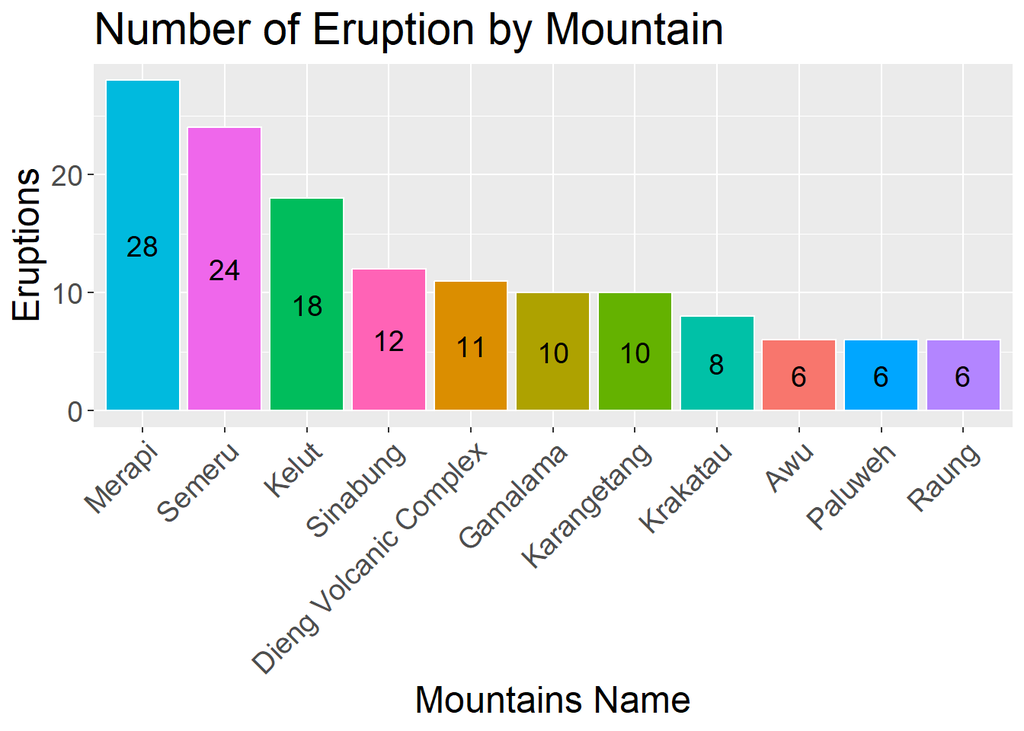

```r
fig(12, 7)
n_eruptbymountain <- v_events %>%
  group_by(name) %>%
  summarise(cnt_bymount=n()) %>%
  arrange(desc(cnt_bymount))

top10_eruptbymountain <- n_eruptbymountain %>% top_n(10) %>% arrange(desc(cnt_bymount))
ggplot(data=top10_eruptbymountain, aes(x=reorder(name, -cnt_bymount), y=cnt_bymount, fill=name)) +
  geom_bar(stat="identity", width=0.9, color="white") +
  scale_x_discrete(guide = guide_axis(angle=45)) +
  geom_text(aes(label=cnt_bymount), position=position_stack(vjust=0.5), size=5) +
  labs(title="Number of Eruption by Mountain") +
  xlab("Mountains Name") +
  ylab("Eruptions") +
  theme(legend.position = "none", text = element_text(size=18))
```

## Índice de Explosividad Volcánica (VEI)

Es un sistema de clasificación muy utilizado para describir el tamaño de las erupciones explosivas. Su fundamento principal radica en la cantidad de masa o volumen expulsado durante la erupción, como se estableció en 1982 por Newhall y Self. Las erupciones históricas que claramente fueron explosivas pero no cuentan con otra información descriptiva se les asigna un VEI predeterminado de 2. Este índice varía de 0 a 8.

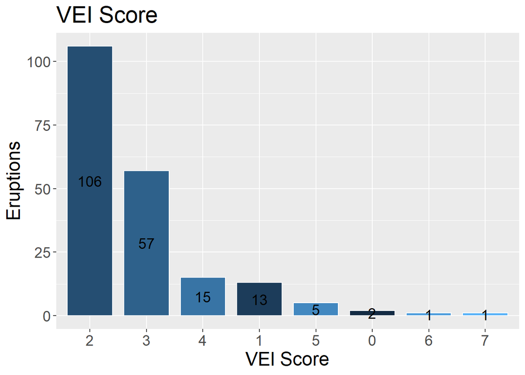

```r
vei_eruptions <- v_events %>% group_by(vei) %>% summarise(cnt_vei=n())
ggplot(data=vei_eruptions, aes(x=reorder(vei, -cnt_vei), y=cnt_vei, fill=vei)) +
  geom_bar(stat="identity", width=0.8, color="white", position = position_dodge(width = 0.1)) +
  geom_text(aes(label=cnt_vei), position=position_stack(vjust=0.5), size=5) +
  labs(title="VEI Score") +
  xlab("VEI Score") +
  ylab("Eruptions") +
  theme(legend.position = "none", text = element_text(size=18))
```

## Erupciones por tipo de montaña

Se muestra el número de erupciones por tipo de montaña:

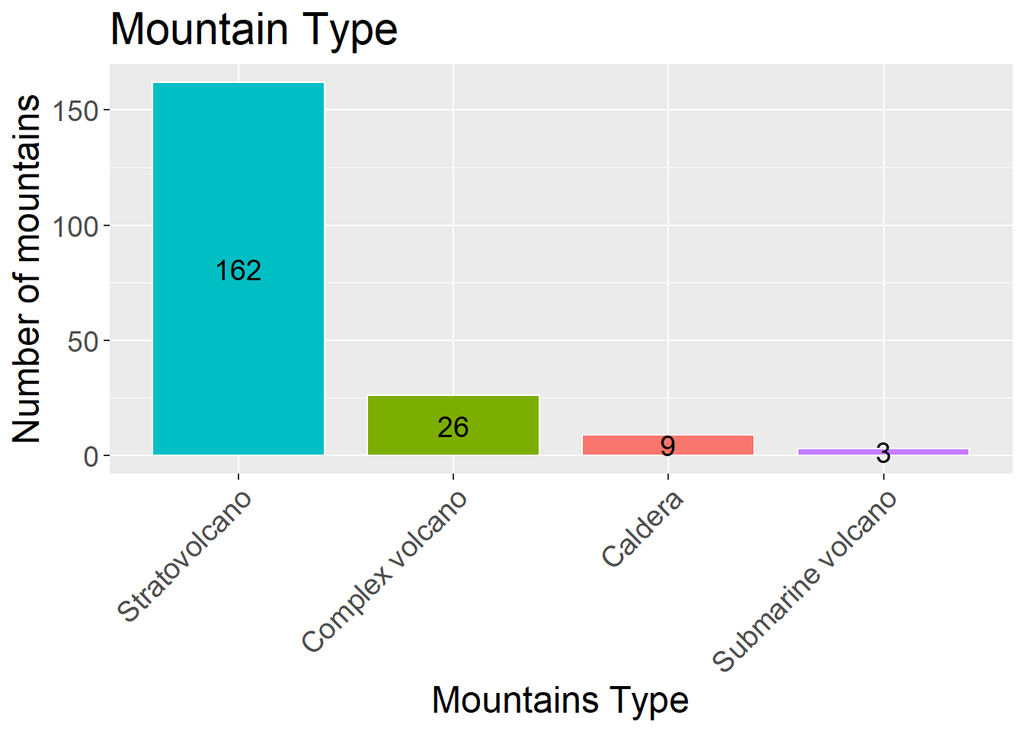

```r
n_eruptbytype <- v_events %>%
  group_by(type) %>%
  summarise(cnt_bytype=n())
ggplot(data=n_eruptbytype, aes(x=reorder(type, -cnt_bytype), y=cnt_bytype, fill=type)) +
      geom_bar(stat="identity", width=0.8, color="white", position = position_dodge(width = 0.1)) +
      geom_text(aes(label=cnt_bytype), position=position_stack(vjust=0.5), size=5) +
      scale_x_discrete(guide = guide_axis(angle=45)) +
      labs(title="Mountain Type") +
      xlab("Mountains Type") +
      ylab("Number of mountains") +
      theme(legend.position = "none", text = element_text(size=18))
```

## By Mountain Elevation

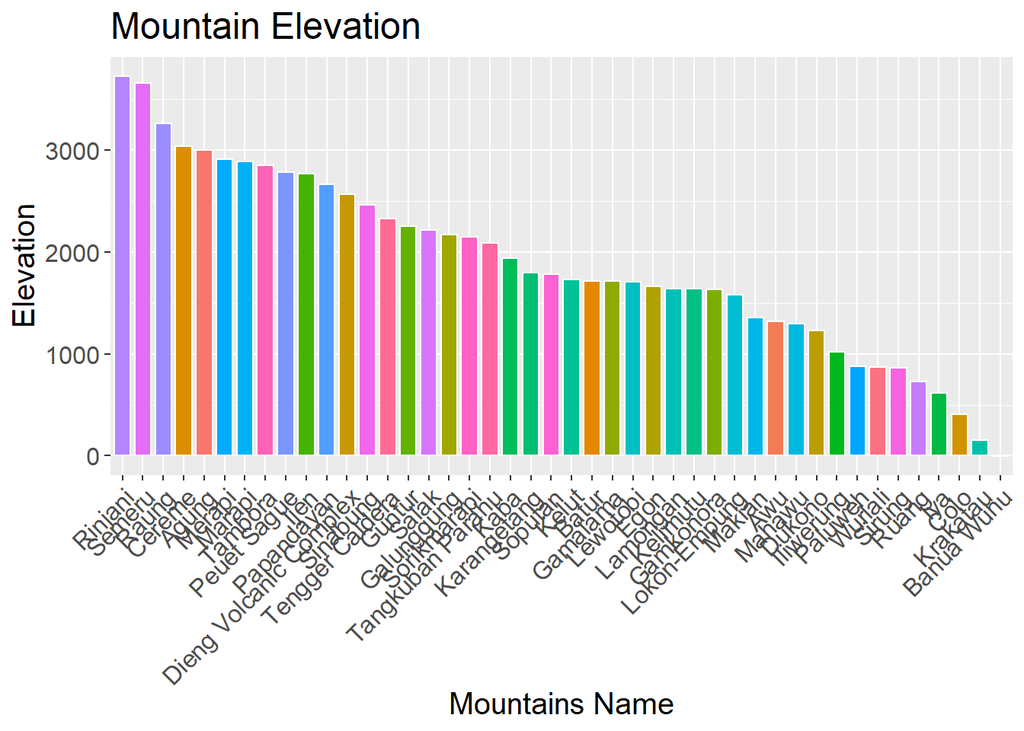

```r
fig(12,7)
e_mounts <- v_events %>% select(name, elevation_m) %>% distinct()
ggplot(data=e_mounts, aes(x=reorder(name, -elevation_m), y=elevation_m, fill=name)) +
  geom_bar(stat="identity", width=0.8, color="white", position = position_dodge(width = 0.1)) +
  scale_x_discrete(guide = guide_axis(angle=45)) +
  # geom_text(aes(label=elevation_m), position=position_stack(vjust=0.5), size=5) +
  labs(title="Mountain Elevation") +
  xlab("Mountains Name") +
  ylab("Elevation") +
  theme(legend.position = "none", text = element_text(size=15))
```

## Erupciones mortales

Aunque las erupciones extremadamente violentas que provocan pérdidas humanas son poco frecuentes, es esencial estar atentos a estos eventos cuando ocurren. La comprensión de estos fenómenos naturales puede contribuir significativamente a la prevención y mitigación de los riesgos asociados con las erupciones volcánicas. Por lo tanto, es crucial realizar un seguimiento cuidadoso de las erupciones, así como estudiar y analizar sus causas y efectos para garantizar una mejor preparación y respuesta ante posibles futuros eventos catastróficos.

```r
n_deathspereruptions <- v_events %>% select(name, erupt_date, total_deaths) %>% arrange(desc(total_deaths)) %>% top_n(10)
```

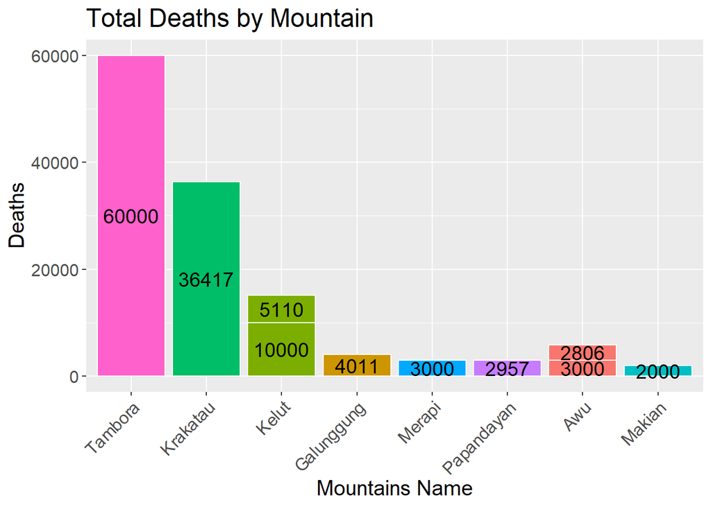

```r
ggplot(data=n_deathspereruptions, aes(x=reorder(name, -total_deaths), y=total_deaths, fill=name)) +
  geom_bar(stat="identity", width=0.9, color="white") +
  scale_x_discrete(guide = guide_axis(angle=45)) +
  geom_text(aes(label=total_deaths), position=position_stack(vjust=0.5), size=5) +
  labs(title="Total Deaths by Mountain") +
  xlab("Mountains Name") +
  ylab("Deaths") +
  theme(legend.position = "none", text = element_text(size=15))
```

## Análisis de Distribución Normal

El histograma ofrece una visión visual de las erupciones a lo largo de los años, mostrando cuántas ocurrieron en cada año. Esta representación nos permite identificar patrones y tendencias en la actividad volcánica con el tiempo. Ayuda a comprender la frecuencia y la distribución de las erupciones, lo que puede ser útil para evaluar el riesgo volcánico y tomar decisiones informadas sobre la gestión de desastres.

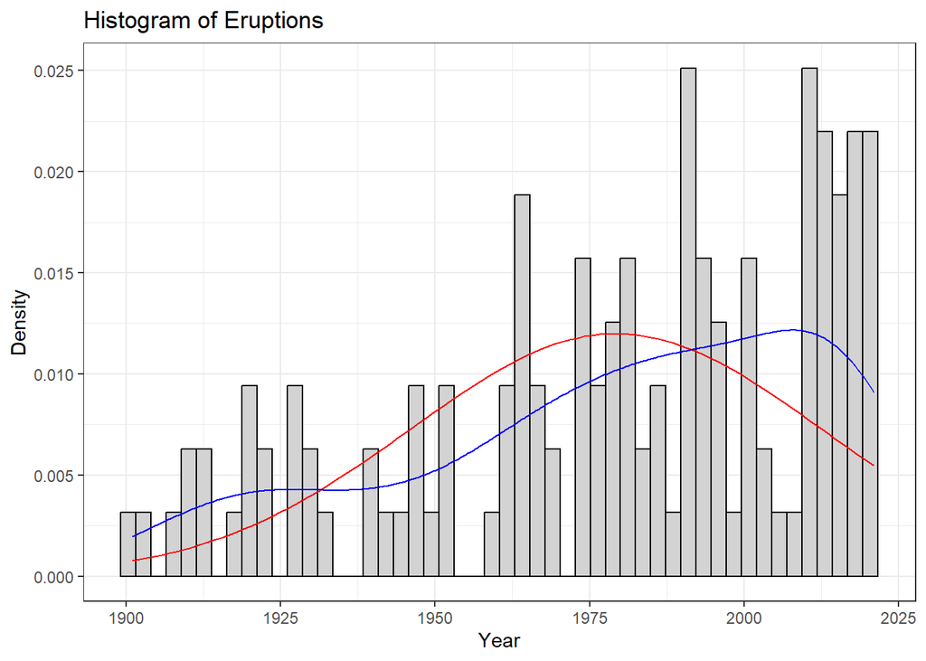

```r
n_mounts <- v_events %>% select(year) %>% filter(year>1900)

ggplot(n_mounts, aes(year)) +
  geom_histogram(aes(x=year, y=..density..), bins = 50, fill="#d3d3d3", color="black") +
  stat_function(fun=dnorm, args = list(mean=mean(n_mounts$year), sd=sd(n_mounts$year)), color="red") +
  geom_density(color="blue") +
  ggtitle("Histogram of Eruptions") +
  xlab("Year") +
  ylab("Density") +
  theme_bw()
```

El gráfico muestra la distribución normal de las elevaciones de las montañas.

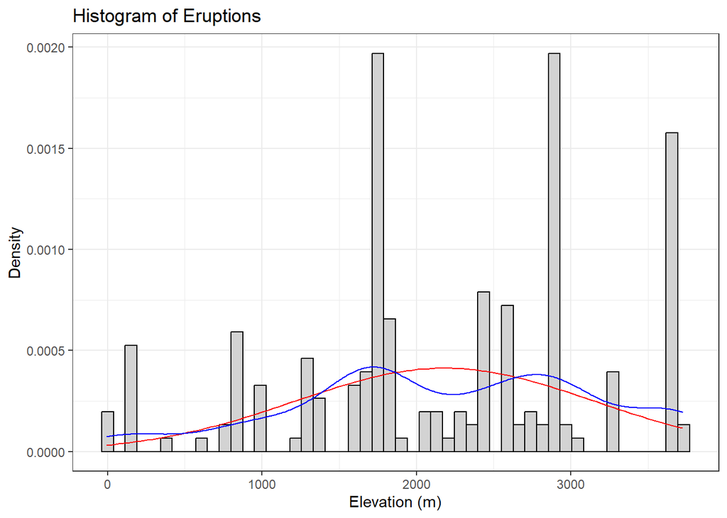

```r
e_mounts <- v_events %>% select(elevation_m)
ggplot(e_mounts, aes(elevation_m)) +
  geom_histogram(aes(x=elevation_m, y=..density..), bins = 50, fill="#d3d3d3", color="black") +
  stat_function(fun=dnorm, args = list(mean=mean(e_mounts$elevation_m), sd=sd(e_mounts$elevation_m)), color="red") +
  geom_density(color="blue") +
  ggtitle("Histogram of Eruptions") +
  xlab("Elevation (m)") +
  ylab("Density") +
  theme_bw()
```

## Analisis de QQ

Un gráfico QQ representa gráficamente datos en función de las cantidades de la variable proporcionada frente a los cuantiles que existirían si los datos siguieran una distribución normal. Se espera que los datos que siguen una distribución normal se encuentren en una línea con una pendiente específica. Al utilizar **`stat_qq()`**, se crea un gráfico QQ. El siguiente ejemplo muestra un gráfico QQ de la variable “erupciones” (n_erupts).

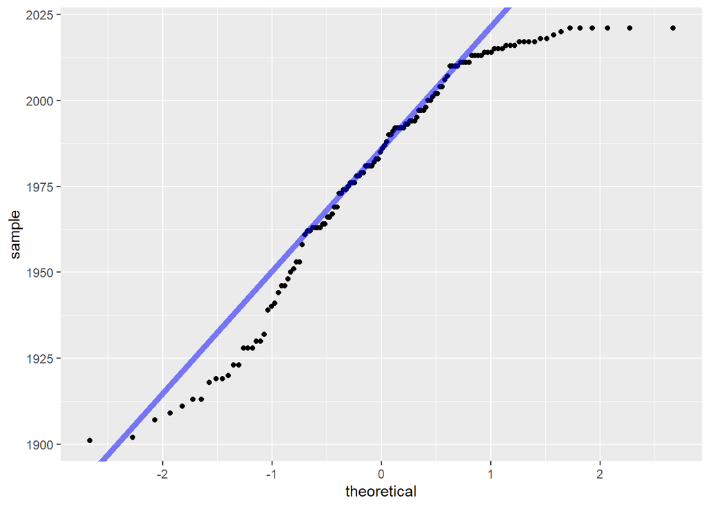

```r
y     <- quantile(n_mounts$year, c(0.25, 0.75)) # Find the 1st and 3rd quantiles
x     <- qnorm( c(0.25, 0.75))           # Find the matching normal values on the x-axis
slope <- diff(y) / diff(x)               # Compute the line slope
int   <- y[1] - slope * x[1]             # Compute the line intercept

ggplot(n_mounts, aes(sample = year)) +
  stat_qq() +
  geom_abline(intercept = int, slope = slope, color = "blue", size = 2, alpha = 0.5 )
```

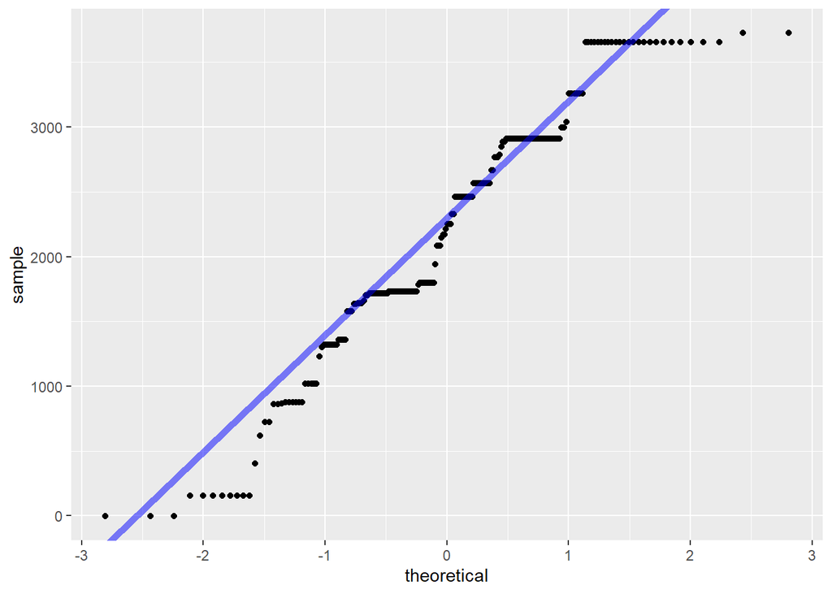

```r
y     <- quantile(e_mounts$elevation_m, c(0.25, 0.75)) # Find the 1st and 3rd quantiles
x     <- qnorm( c(0.25, 0.75))           # Find the matching normal values on the x-axis
slope <- diff(y) / diff(x)               # Compute the line slope
int   <- y[1] - slope * x[1]             # Compute the line intercept

ggplot(e_mounts, aes(sample = elevation_m)) +
  stat_qq() +
  geom_abline(intercept = int, slope = slope, color = "blue", size = 2, alpha = 0.5 )
```

## Correlación con la elevación

```r
library(colorspace)
```

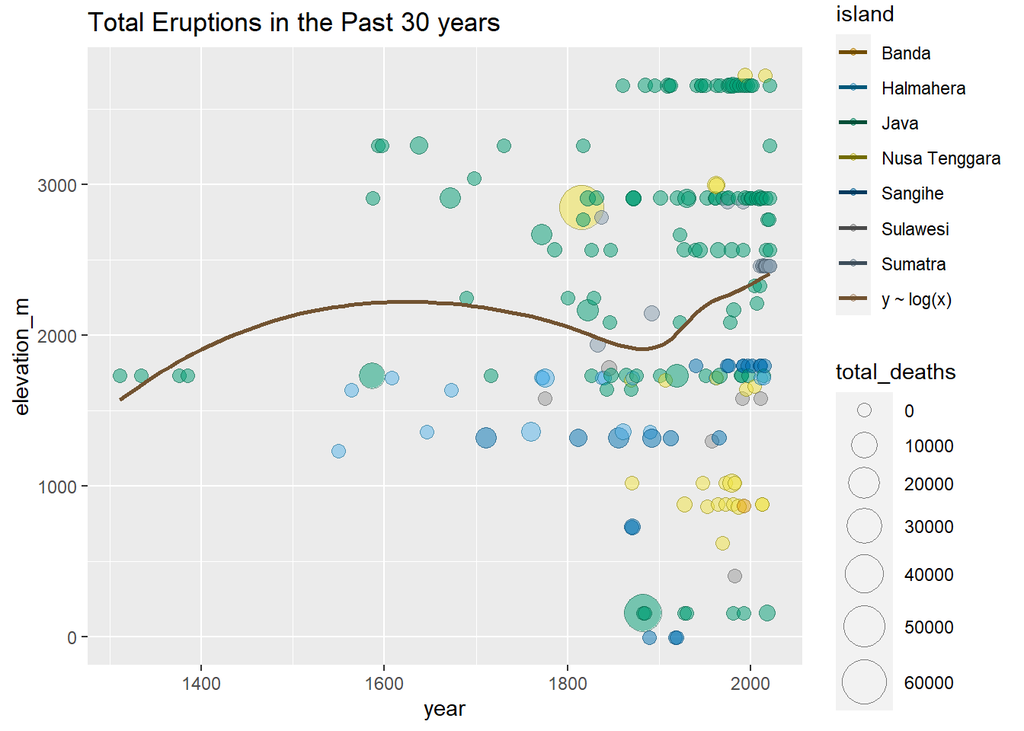

```r
fig(12, 7)
island_cols <- c("#E69F00", "#56B4E9", "#009E73", "#F0E442", "#0072B2", "#999999", "#889EAF", "#D4B499")
e_events <- v_events
ggplot(data=e_events, aes(x=year, y=elevation_m)) +
  geom_point(aes(color = island, fill = island, size = total_deaths), alpha = 0.5, shape = 21) +
  geom_smooth(
        aes(color = "y ~ log(x)", fill = "y ~ log(x)"),
        method = 'loess', formula = y~log(x), se = FALSE, fullrange = TRUE) +
  scale_size_continuous(range = c(3, 10)) +
  scale_color_manual(values = darken(island_cols, 0.5)) +
  scale_fill_manual(values = island_cols) +
  labs(title="Total Eruptions in the Past 30 years")
```

Después de 1970, las erupciones muestran un incremento en la actividad volcánica. Al observar los datos solo desde 1970 en adelante, se nota que, aunque la actividad volcánica en las montañas ha ido en aumento desde 1800, el impacto, en términos de número de muertes y lesiones, está disminuyendo.

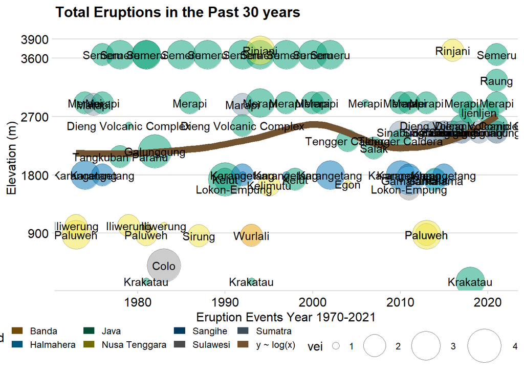

```r
fig(18, 12)
e_events_1970 <- v_events %>% filter(year>1970 & elevation_m>0)
# e_events_top10 <- e_events_1970 %>% filter(vei>2)
ggplot(data=e_events_1970, aes(x=year, y=elevation_m)) +
  geom_point(aes(color = island, fill = island, size = vei), alpha = 0.5, shape = 21) +
  geom_smooth(aes(color = "y ~ log(x)", fill = "y ~ log(x)", alpha=.1), size=3,
    method = 'loess', formula = y~log(x), se = FALSE, fullrange = TRUE) +
  geom_text(
    aes(label = name),
    color = "black",
    size = 11/.pt, # font size 9 pt
    point.padding = 0.1,
    box.padding = .6,
    min.segment.length = 0,
    max.overlaps = 1000,
    seed = 7654
  ) +
  scale_size_continuous(range = c(3, 15)) +
  scale_color_manual(values = darken(island_cols, 0.5)) +
  scale_fill_manual(values = island_cols) +
  scale_x_continuous(
    name = "Eruption Events Year 1970-2021",
  ) +
  scale_y_continuous(
    name = "Elevation (m)",
    limits = c(10, 4100),
    breaks = c(1, 900, 1800, 2700, 3600, 3900),
    expand = c(0, 0)
  ) +
  labs(title="Total Eruptions in the Past 30 years") +
  theme_minimal_hgrid(12, rel_small = 1) +
  theme(
    legend.position = "bottom",
    legend.justification = "right",
    legend.text = element_text(size = 9),
    legend.box.spacing = unit(0, "pt")
  )
```

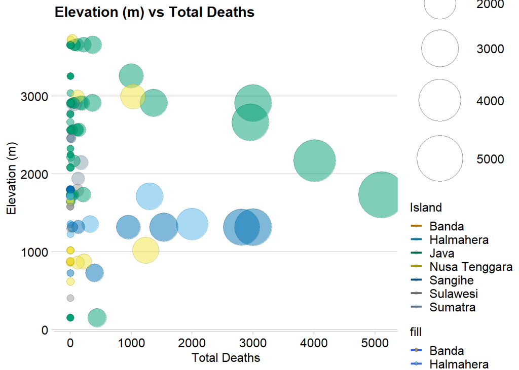

```r
fig(12, 7)
island_cols <- c("#E69F00", "#56B4E9", "#009E73", "#F0E442", "#0072B2", "#999999", "#889EAF", "#D4B499")
ve_data <- v_events %>% filter(elevation_m>0 & total_deaths<10000) %>% select(island, type, name, vei, elevation_m, total_deaths)
ggplot(ve_data, aes(total_deaths, elevation_m)) +
  geom_smooth(aes(color = "y ~ log(x)", fill = "y ~ log(x)"),
        method = 'lm', formula = y~log(x), se = FALSE, fullrange = TRUE) +
  geom_point(aes(color = island, fill = island, size = total_deaths), alpha = 0.5, shape = 21) +
  labs(title="Elevation (m) vs Total Deaths") +
  xlab("Total Deaths") +
  ylab("Elevation (m)") +
  scale_color_manual(values = darken(island_cols, 0.3)) +
  scale_fill_manual(values = island_cols) +
  scale_size_continuous(range = c(3, 21)) +
  guides(size=guide_legend("Total Deaths")) +
  guides(colour=guide_legend("Island")) +
  theme_minimal_hgrid(12, rel_small = 1)
```

## Mapa de volcanes

Mostrar datos en un mapa es esencial para representar la ubicación de los objetos discutidos y, al mismo tiempo, para visualizar más información que se pueda relacionar con el mapa.

```r
library(maps)
fig(20, 9)

island_cols <- c("#E69F00", "#56B4E9", "#009E73", "#F0E442", "#0072B2", "#999999", "#889EAF", "#D4B499")
type_cols <- c("#6F69AC", "#95DAC1", "#FFEBA1", "#FD6F96")

mydata <- e_events %>%
  group_by(island, type, name, longitude, latitude) %>%
  summarise(sum_erpt = n(), m_vei = mean(vei), m_elev = max(elevation_m), m_deaths = max(total_deaths))
```

```
## can override using the `.groups` argument.
```

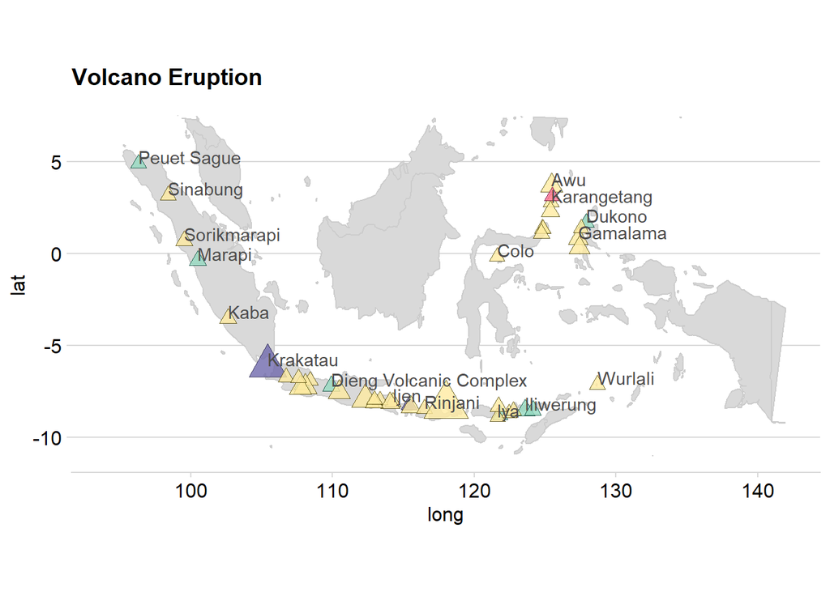

```r
# World longitude and latitude data
global <- map_data("world")

ggplot() +
  geom_polygon(data = global, aes(x=long, y = lat, group = group),
               fill = "gray85", color = "gray80") +
  coord_fixed(1.3) +
  xlim(94,142) + ylim(-11,7.5) +
  geom_point(data = mydata, aes(x = longitude, y = latitude, color = type, fill = type, size = m_deaths),
             alpha = 0.8, show.legend = FALSE, shape=24) +
  geom_text(
    data = mydata,
    aes(x = longitude, y = latitude, label = name),
    color = "grey30",
    size = 11/.pt, # font size 9 pt
    check_overlap = TRUE,
    hjust = 0, vjust = 0
  ) +
  ggtitle("Volcano Eruption") +
  scale_color_manual(values = darken(type_cols, 0.7)) +
  scale_fill_manual(values = type_cols) +
  scale_size_continuous(range = c(3, 9), name = "Total Deaths") +
  theme_minimal_hgrid(12, rel_small = 1) +
  theme(
    legend.position = "bottom",
    legend.justification = "right",
    legend.text = element_text(size = 9),
    legend.box.spacing = unit(3, "pt")
  )
```

# Conclusiones

Basándonos en la visualización de datos y en métodos estadísticos, podemos sacar las siguientes conclusiones de la información disponible:

# Referencias:

NCEI/WDS Global Significant Volcanic Eruptions Database, 4360 BC to Present Personal research for the year 2021 volcanic eruptions, from local online news media.

Visualizing Data, Probability, the Normal Distribution, and Z Scores Brief History of Volcano Eruptions in Indonesia, Viz of the day, Tableau Public Gallery.

https://www.kaggle.com/code/corneliuskristianto/volcano-eruption-in-indonesia